# case_study_umaer_jayanth#1

#### Contact Address vs Work Address

- From the above plot and proportions, we can clearly notice that 82% of them live and work in same city.
- Out of that 82%, 7.66% of applicants likely to have payment difficulties.
- From the above plot and proportions, we can clearly notice that 17% of them donot live and work in same city.
- Out of that 17%, 9.97% of applicants have payment difficulties.

**By this, we can clearly infer that, applicants that live and work in same city are at less risk of payment difficulties.**

```
TARGET 0
 [0, 1]
Categories (2, int64): [0, 1]

TARGET 1
 [0, 1]
Categories (2, int64): [0, 1]

All Other Cases (TARGET : 0)
+----+--------------------------+---------+-----------+--------------------+----------------------+
|    |   REG_CITY_NOT_LIVE_CITY |   Count |   Percent |   Cumulative Count |   Cumulative Percent |
|----+--------------------------+---------+-----------+--------------------+----------------------|
|  0 |                        0 |  261586 | 0.925359  |             261586 |             0.925359 |
|  1 |                        1 |   21100 | 0.0746411 |             282686 |             1        |
+----+--------------------------+---------+-----------+--------------------+----------------------+

Clients with Payment Difficulties (TARGET : 1)
+----+--------------------------+---------+-----------+--------------------+----------------------+
|    |   REG_CITY_NOT_LIVE_CITY |   Count |   Percent |   Cumulative Count |   Cumulative Percent |
|----+--------------------------+---------+-----------+--------------------+----------------------|
|  0 |                        0 |   21886 |  0.881611 |              21886 |             0.881611 |
|  1 |                        1 |    2939 |  0.118389 |              24825 |             1        |
+----+--------------------------+---------+-----------+--------------------+----------------------+

Proportion of 0 in Target 0 :  92.28
Proportion of 0 in Target 1 :  7.72

Proportion of 1 in Target 0 :  87.77
Proportion of 1 in Target 1 :  12.23
```

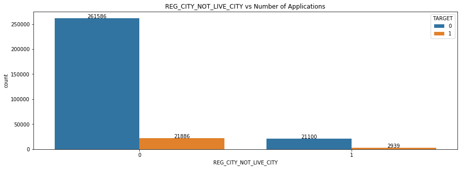

```python
#REG_CITY_NOT_LIVE_CITY.
cat_univariate_analysis('REG_CITY_NOT_LIVE_CITY',figsize=(15,5))
cat_proportions('REG_CITY_NOT_LIVE_CITY')
```

#### Permanent Address vs Contact Address

- From the above plot and proportions,92% of the applicant's permanent and contact address are same.
- Out of that 92%, 7.72% of applicants likely to have payment difficulties.
- From the above plot and proportions, 8% of the applicant's permanent and contact address are not same.
- Out of that 8%, 12.23% of applicants likely to have payment difficulties.

**By this, we can infer that, applicants that same permanent and contact address are likely to have less risk of payment difficulties.**

```
TARGET 0
 [0, 1]
Categories (2, int64): [0, 1]

TARGET 1
 [0, 1]
Categories (2, int64): [0, 1]

All Other Cases (TARGET : 0)
+----+--------------------------+---------+-----------+--------------------+----------------------+
|    |   REG_CITY_NOT_WORK_CITY |   Count |   Percent |   Cumulative Count |   Cumulative Percent |
|----+--------------------------+---------+-----------+--------------------+----------------------|
|  0 |                        0 |  219339 |   0.77591 |             219339 |              0.77591 |
|  1 |                        1 |   63347 |   0.22409 |             282686 |              1       |
+----+--------------------------+---------+-----------+--------------------+----------------------+

Clients with Payment Difficulties (TARGET : 1)
+----+--------------------------+---------+-----------+--------------------+----------------------+
|    |   REG_CITY_NOT_WORK_CITY |   Count |   Percent |   Cumulative Count |   Cumulative Percent |
|----+--------------------------+---------+-----------+--------------------+----------------------|
|  0 |                        0 |   17305 |   0.69708 |              17305 |              0.69708 |
|  1 |                        1 |    7520 |   0.30292 |              24825 |              1       |
+----+--------------------------+---------+-----------+--------------------+----------------------+

Proportion of 0 in Target 0 :  92.69
Proportion of 0 in Target 1 :  7.31

Proportion of 1 in Target 0 :  89.39
Proportion of 1 in Target 1 :  10.61
```

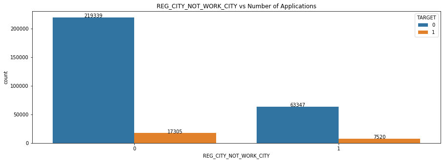

```python
#REG_CITY_NOT_WORK_CITY.
cat_univariate_analysis('REG_CITY_NOT_WORK_CITY',figsize=(15,5))
cat_proportions('REG_CITY_NOT_WORK_CITY')
```

#### Permanent Address vs Work Address

- From the above plot and proportions, we can notice that 77% of applicants permanent address and work address are same. Coming to other side, 23% of applicants permanent address and work address are not same.
- Looking at the proportions of "Clients with payment difficulties" on both sides, we can infer that the applicants whose permanent adress and work adress matches are less likely to have payment difficulties.

## Bivariate Analysis

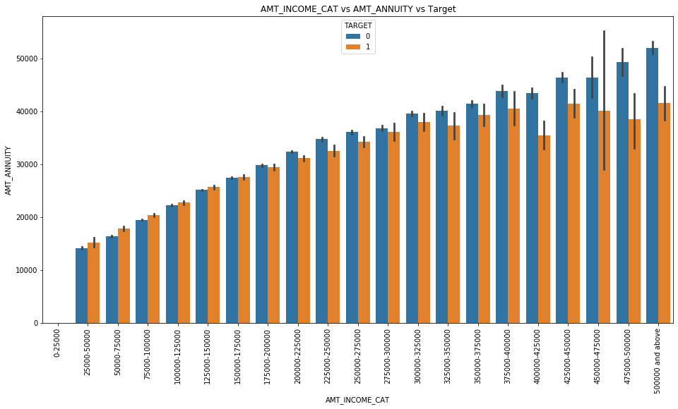

```python
#AMT_ANNUITY, AMT_INCOME_TOTAL vs TARGET
column_names = ['AMT_INCOME_CAT','AMT_ANNUITY']
plt.figure(figsize=(16,8))
sns.barplot(x = column_names[0],y = column_names[1],hue='TARGET',data = application_data)
plt.title(column_names[0] + ' vs '+ column_names[1] + ' vs Target')
plt.xticks(rotation=90);
```

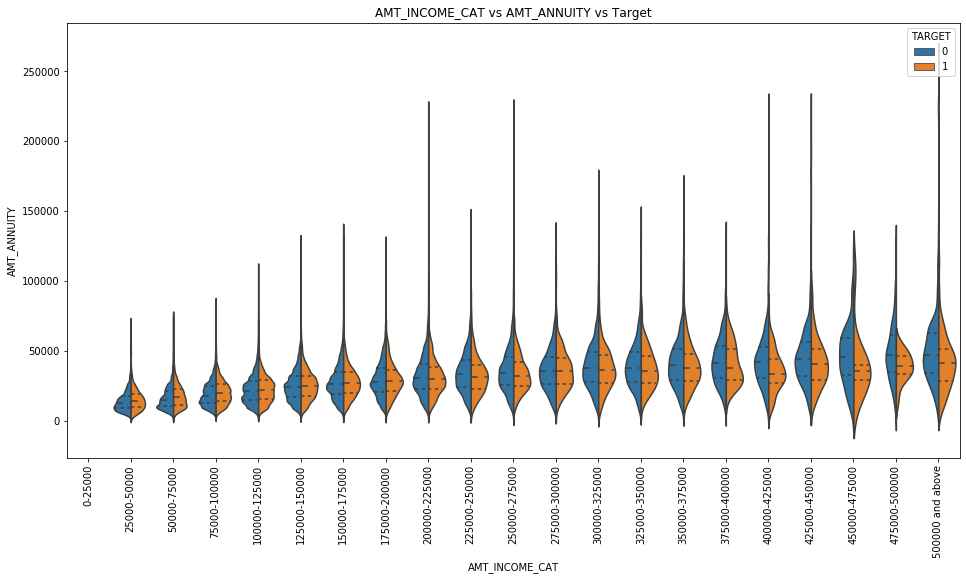

```python
plt.figure(figsize=(16,8))
# sns.catplot(x = column_names[0],y =column_names[1],hue='TARGET',data = application_data, kind='violin',height=8,aspect=4);
sns.violinplot(x = 'AMT_INCOME_CAT',y='AMT_ANNUITY',hue='TARGET',data = application_data,split=True, inner="quartile")
plt.title(column_names[0] + ' vs '+ column_names[1] + ' vs Target')
plt.xticks(rotation=90);
```

#### Income and Annuity

- Both plots show a gradual increase in the amount of annuity with increase in income.
- Also, as the income increases there are higher number of outliers i.e the propensity to take on very high annuities compared to most customers in the same income range.
- It can be seen that in low income ranges, the median no of "Clients with Payment difficulties' is slightly higher.
- And the in high income ranges,the median no of "Clients with Payment difficulties' is slightly lower.

**Income Range and Annuity have a mild correlation with Payment difficulties**

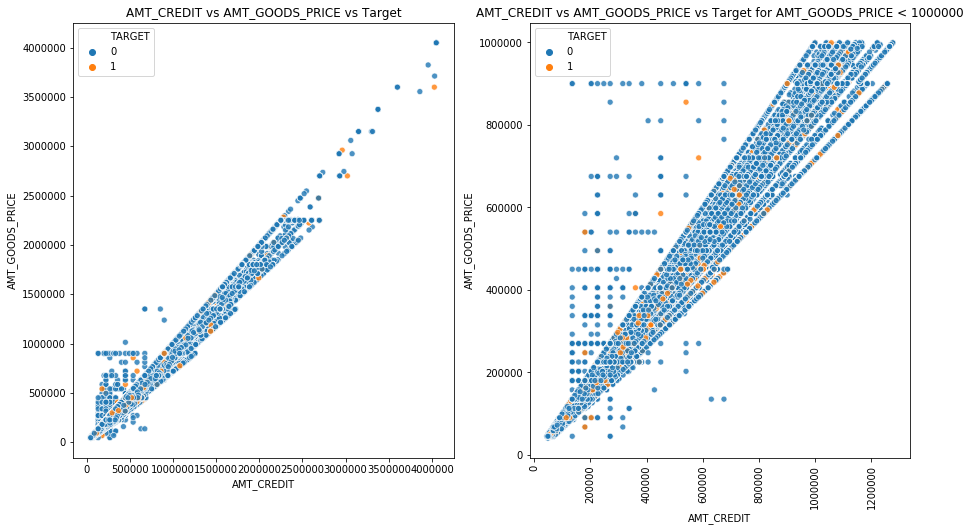

```python
#AMT_CREDIT, AMT_GOODS_PRICE vs TARGET
column_names = ['AMT_CREDIT', 'AMT_GOODS_PRICE']
fig,ax = plt.subplots(1,2)
fig.set_figheight(8)
fig.set_figwidth(15)

ax[0].set(title = column_names[0] + ' vs '+ column_names[1] + ' vs Target');
sns.scatterplot(x=column_names[0],y=column_names[1],hue='TARGET',data=application_data, alpha=0.8,ax=ax[0])
plt.xticks(rotation=90);

plt.title(column_names[0] + ' vs '+ column_names[1] + ' vs Target for AMT_GOODS_PRICE < 1000000');
sns.scatterplot(x=column_names[0],y=column_names[1],hue='TARGET',data=application_data[application_data['AMT_GOODS_PRICE'] <=1000000], alpha=0.8,ax=ax[1])
plt.xticks(rotation=90);
```

#### Credit Amount and Price of Credit Goods

- There is an overall linear relationship between Credit Amount and Price of Credit Goods.
- Notice that more clients with payment difficulties are the ones who have borrowed lesser money for lesser priced goods.
- And most outliers do not have payment difficulties.

**Lower Credit Amount and Lower Price of Credit Goods have higher cases of Payment difficulties**

```python
#NAME_CONTRACT_TYPE vs REGION_RATING_CLIENT_W_CITY vs TARGET

column_names = ['NAME_CONTRACT_TYPE','REGION_RATING_CLIENT_W_CITY']
application_data.groupby(column_names)['TARGET'].value_counts(normalize=True)
```

```
NAME_CONTRACT_TYPE  REGION_RATING_CLIENT_W_CITY  TARGET
Cash loans          1                            0        0.95
                                                 1        0.05
                    2                            0        0.92
                                                 1        0.08
                    3                            0        0.88
                                                 1        0.12
Revolving loans     1                            0        0.97
                                                 1        0.03
                    2                            0        0.94
                                                 1        0.06
                    3                            0        0.93
                                                 1        0.07
Name: TARGET, dtype: float64
```

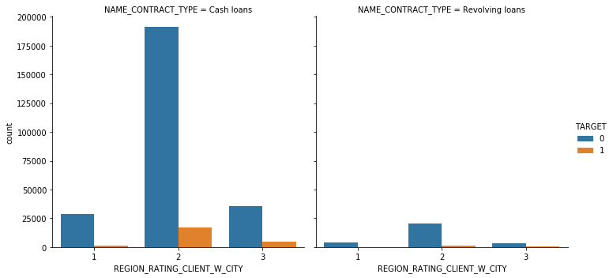

```python
sns.catplot(x='REGION_RATING_CLIENT_W_CITY', hue='TARGET', col="NAME_CONTRACT_TYPE", kind="count", data=application_data);
```

#### Type of Loan and City Rating

- In cash loans, Category 3 Cities have **7%** more probability of payment difficulties than Category 1 Cities.
- In Revolving loans, Category 3 Cities have **4%** more probability of payment difficulties than Category 1 Cities.

Although this just confirms correlation between the City Rating and default, now we know that **city rating has a higher impact on Cash Loans than Revolving Loans**

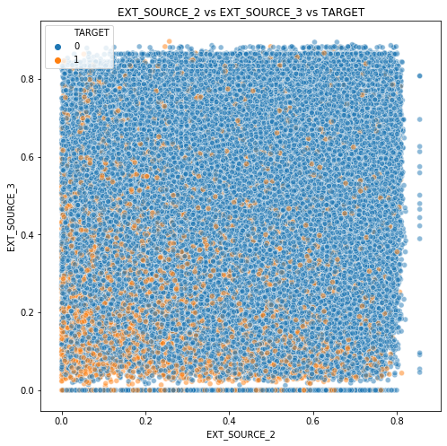

```python
# EXT_SOURCE_2 vs EXT_SOURCE_3 vs TARGET
creditScores = ['EXT_SOURCE_2','EXT_SOURCE_3']
plt.figure(figsize=[8,8])
sns.scatterplot(x=creditScores[0],y = creditScores[1], hue='TARGET',data = application_data, alpha=0.5);
plt.title(creditScores[0] + ' vs '+ creditScores[1]+ ' vs '+ 'TARGET');
```

#### Credit Rating

- Checking Credit Ratings from two different sources confirms that trend of customers with lower credit ratings have a higher default rate.

```python
#FLAG_OWN_CAR vs FLAG_OWN_REALTY vs TARGET
application_data.groupby(['FLAG_OWN_CAR','FLAG_OWN_REALTY'])['TARGET'].value_counts(normalize=True)
```

```
FLAG_OWN_CAR  FLAG_OWN_REALTY  TARGET
N             N                0        0.91
                               1        0.09
              Y                0        0.92
                               1        0.08
Y             N                0        0.93
                               1        0.07
              Y                0        0.93
                               1        0.07
Name: TARGET, dtype: float64
```

#### Owning A Car & Realty

From the above table , we see that customers with no car or realty have a high probability of default (9%), followed by customers who don't have a car but own realty (8%)  
**Since there's not much difference posed by owning a car or realty vs not owning them, we cannot infer any trend in default using these variables**

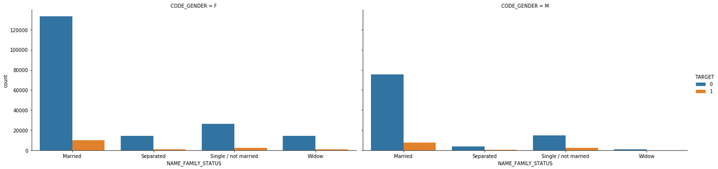

```python
#CODE_GENDER vs NAME_FAMILY_STATUS vs TARGET

# For the sake of this analysis since Civil marriage and Married are same, clubbing them into married category
application_data['NAME_FAMILY_STATUS'].replace('Civil marriage','Married', inplace=True)

ax = sns.catplot(x='NAME_FAMILY_STATUS', hue='TARGET', col="CODE_GENDER", kind="count", data=application_data, height = 5, aspect=2);
```

```python
# classification over both categories
pd.DataFrame(application_data.groupby(['CODE_GENDER','NAME_FAMILY_STATUS'])['TARGET'].value_counts(normalize=True))
```

| CODE_GENDER | NAME_FAMILY_STATUS | TARGET | TARGET |
| --- | --- | --- | --- |
| F | Married | 0 | 0.93 |
|  |  | 1 | 0.07 |
|  | Separated | 0 | 0.93 |
|  |  | 1 | 0.07 |
|  | Single / not married | 0 | 0.92 |
|  |  | 1 | 0.08 |
|  | Widow | 0 | 0.95 |
|  |  | 1 | 0.05 |
| M | Married | 0 | 0.91 |
|  |  | 1 | 0.09 |
|  | Separated | 0 | 0.87 |
|  |  | 1 | 0.13 |
|  | Single / not married | 0 | 0.87 |
|  |  | 1 | 0.13 |
|  | Widow | 0 | 0.88 |
|  |  | 1 | 0.12 |

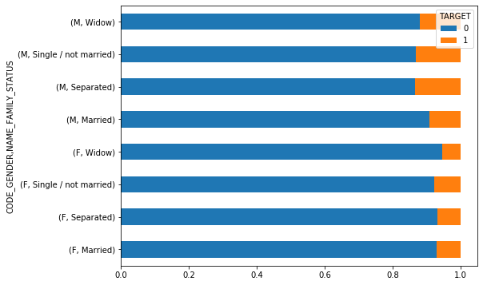

```python
application_data.groupby(['CODE_GENDER','NAME_FAMILY_STATUS'])['TARGET'].value_counts(normalize=True)\
.unstack()\
   .plot(
    layout=(2,2),
    figsize=(8,6), kind='barh', stacked=True);
```

#### Gender & Marital Status

- Looking at the above values, customers most attractive to the bank by likelihood of default, are  
  'Female Widows' > 'Married Females' = 'Separated Females' > 'Single Females' > 'Married Males' > 'Male Widowers' > 'Single Males' = 'Separated Males'

**The bank may focus their marketing campaigns on converting applications of Female Widows, Married Females, Separated Females**  
**May note that the dataset is skewed towards Females than Males**

```python
# NAME_HOUSING_TYPE vs NAME_INCOME_TYPE vs TARGET
income_housing = pd.DataFrame(application_data.groupby(['NAME_HOUSING_TYPE','NAME_INCOME_TYPE'])['TARGET'].value_counts(normalize=True))
income_housing.columns = ['Normalized Count']
income_housing
```

| NAME_HOUSING_TYPE | NAME_INCOME_TYPE | TARGET | Normalized Count |
| --- | --- | --- | --- |
| Co-op apartment | Commercial associate | 0 | 0.91 |
|  |  | 1 | 0.09 |
|  | Pensioner | 0 | 0.96 |
|  |  | 1 | 0.04 |
|  | State servant | 0 | 0.99 |
|  |  | 1 | 0.01 |
|  | Working | 0 | 0.91 |
|  |  | 1 | 0.09 |
| House / apartment | Businessman | 0 | 1.00 |
|  | Commercial associate | 0 | 0.93 |
|  |  | 1 | 0.07 |
|  | Maternity leave | 0 | 0.60 |
|  |  | 1 | 0.40 |
|  | Pensioner | 0 | 0.95 |
|  |  | 1 | 0.05 |
|  | State servant | 0 | 0.94 |
|  |  | 1 | 0.06 |
|  | Student | 0 | 1.00 |
|  | Unemployed | 0 | 0.65 |
|  |  | 1 | 0.35 |
|  | Working | 0 | 0.91 |
|  |  | 1 | 0.09 |
| Municipal apartment | Commercial associate | 0 | 0.92 |
|  |  | 1 | 0.08 |
|  | Pensioner | 0 | 0.93 |
|  |  | 1 | 0.07 |
|  | State servant | 0 | 0.94 |
|  |  | 1 | 0.06 |
|  | Unemployed | 1 | 1.00 |
|  | Working | 0 | 0.90 |
|  |  | 1 | 0.10 |
| Office apartment | Commercial associate | 0 | 0.93 |
|  |  | 1 | 0.07 |
|  | Pensioner | 0 | 0.94 |
|  |  | 1 | 0.06 |
|  | State servant | 0 | 0.96 |
|  |  | 1 | 0.04 |
|  | Student | 0 | 1.00 |
|  | Working | 0 | 0.92 |
|  |  | 1 | 0.08 |
| Rented apartment | Commercial associate | 0 | 0.88 |
|  |  | 1 | 0.12 |
|  | Pensioner | 0 | 0.93 |
|  |  | 1 | 0.07 |
|  | State servant | 0 | 0.93 |
|  |  | 1 | 0.07 |
|  | Student | 0 | 1.00 |
|  | Unemployed | 0 | 1.00 |
|  | Working | 0 | 0.86 |
|  |  | 1 | 0.14 |
| With parents | Commercial associate | 0 | 0.90 |
|  |  | 1 | 0.10 |
|  | Pensioner | 0 | 0.95 |
|  |  | 1 | 0.05 |
|  | State servant | 0 | 0.91 |
|  |  | 1 | 0.09 |
|  | Student | 0 | 1.00 |
|  | Unemployed | 0 | 0.67 |
|  |  | 1 | 0.33 |
|  | Working | 0 | 0.87 |
|  |  | 1 | 0.13 |

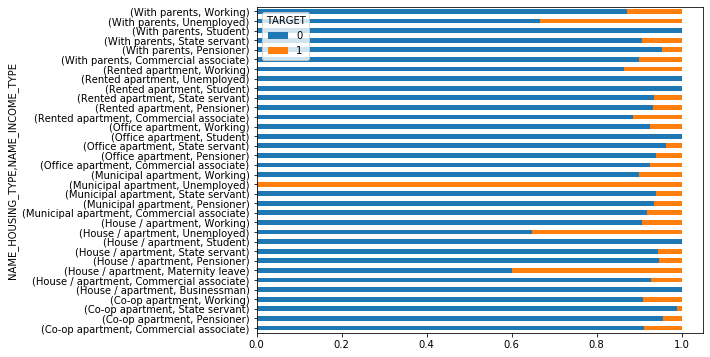

```python
application_data.groupby(['NAME_HOUSING_TYPE','NAME_INCOME_TYPE'])['TARGET'].value_counts(normalize=True)\
.unstack()\
   .plot(
    layout=(2,2),
    figsize=(8,6), kind='barh', stacked=True);
```

```python
income_housing[np.in1d(income_housing.index.get_level_values(2), 1)].sort_values(by='Normalized Count', ascending=True)
```

| NAME_HOUSING_TYPE | NAME_INCOME_TYPE | TARGET | Normalized Count |
| --- | --- | --- | --- |
| Co-op apartment | State servant | 1 | 0.01 |
| Office apartment | State servant | 1 | 0.04 |
| Co-op apartment | Pensioner | 1 | 0.04 |
| With parents | Pensioner | 1 | 0.05 |
| House / apartment | Pensioner | 1 | 0.05 |
|  | State servant | 1 | 0.06 |
| Office apartment | Pensioner | 1 | 0.06 |
| Municipal apartment | State servant | 1 | 0.06 |
| Rented apartment | State servant | 1 | 0.07 |
| Municipal apartment | Pensioner | 1 | 0.07 |
| Rented apartment | Pensioner | 1 | 0.07 |
| House / apartment | Commercial associate | 1 | 0.07 |
| Office apartment | Commercial associate | 1 | 0.07 |
|  | Working | 1 | 0.08 |
| Municipal apartment | Commercial associate | 1 | 0.08 |
| Co-op apartment | Commercial associate | 1 | 0.09 |
|  | Working | 1 | 0.09 |
| House / apartment | Working | 1 | 0.09 |
| With parents | State servant | 1 | 0.09 |
|  | Commercial associate | 1 | 0.10 |
| Municipal apartment | Working | 1 | 0.10 |
| Rented apartment | Commercial associate | 1 | 0.12 |
| With parents | Working | 1 | 0.13 |
| Rented apartment | Working | 1 | 0.14 |
| With parents | Unemployed | 1 | 0.33 |
| House / apartment | Unemployed | 1 | 0.35 |
|  | Maternity leave | 1 | 0.40 |
| Municipal apartment | Unemployed | 1 | 1.00 |

#### Housing Type & Income Type

- The above tables list the categories in the order of least likelihood of Payment difficulties
- The top 5 categories are :
  - State servant living in Co-op apartment
  - State servant living in Office apartment
  - Pensioner living in Co-op apartment
  - Pensioner living With parents
  - Pensioner living in House / apartment

**The bank may focus their marketing campaigns on converting applications of the above categories**  
**Pensioner living With parents category doesn't seem right and may be further checked if it's an anomaly**

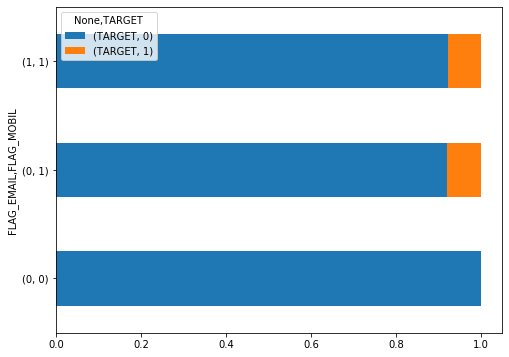

```python
#FLAG_EMAIL vs FLAG_MOBIL vs TARGET
pd.DataFrame(application_data.groupby(['FLAG_EMAIL','FLAG_MOBIL'])['TARGET'].value_counts(normalize=True))\
.unstack()\
   .plot(
    layout=(2,2),
    figsize=(8,6), kind='barh', stacked=True);
```

```python
pd.DataFrame(application_data.groupby(['FLAG_EMAIL','FLAG_MOBIL'])['TARGET'].value_counts())
```

| FLAG_EMAIL | FLAG_MOBIL | TARGET | TARGET |
| --- | --- | --- | --- |
| 0 | 0 | 0 | 1 |
|  | 1 | 0 | 266617 |
|  |  | 1 | 23451 |
| 1 | 1 | 0 | 16068 |
|  |  | 1 | 1374 |

#### Email & Mobile Information

- 8% of customers who have not provided Email but have provided a Mobile Number have had payment difficulties
- Similarly 8% of customers who provided both Email and Mobile Number have had payment difficulties

**Hence we cannot infer any conclusive trend in payment difficulties using these variables**

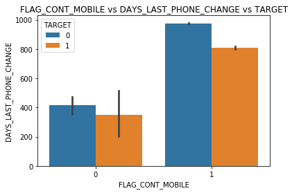

```python
# DAYS_LAST_PHONE_CHANGE vs FLAG_CONT_MOBILE vs TARGET

sns.barplot(x = 'FLAG_CONT_MOBILE', y= 'DAYS_LAST_PHONE_CHANGE', hue='TARGET',data = application_data)
plt.title("FLAG_CONT_MOBILE vs DAYS_LAST_PHONE_CHANGE vs TARGET")
```

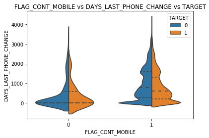

```python
sns.violinplot(x = 'FLAG_CONT_MOBILE', y= 'DAYS_LAST_PHONE_CHANGE', hue='TARGET', split=True, data = application_data,inner="quartile", height=5, aspect=1)
plt.title("FLAG_CONT_MOBILE vs DAYS_LAST_PHONE_CHANGE vs TARGET")
```

#### Days Since Phone Number Changed & Whether was Phone was Reachable

- Notice that the number of clients with reachable phones is higher than unreachable phones. (~900 days vs ~350 days)
- Among clients with reachable phones, Clients with Payment difficulties have median newer phone numbers than All other cases. (See violin plot for FLAG_CONT_MOBILE = 1 )
- Among clients with unreachable phones, the difference is less (~50 days vs ~ 200 days). In fact, the median age of phone number is same for defaulters and others.

**We could conclude that clients with reachable and older phone numbers are better borrowers than other categories.When the phone is unreachable, last date of phone number change doesn't matter.**

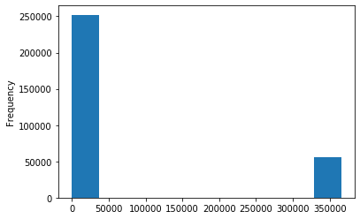

```python
application_data['DAYS_EMPLOYED'].plot.hist()
```

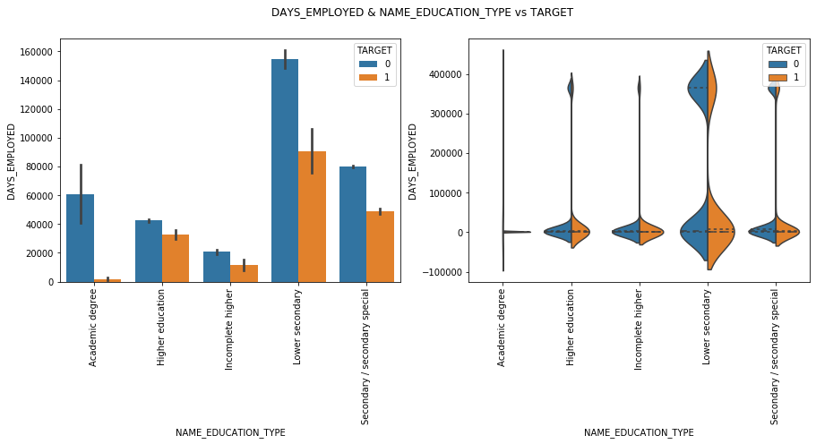

```python
#DAYS_EMPLOYED & NAME_EDUCATION_TYPE vs TARGET
fig,ax = plt.subplots(1,2)
fig.set_figheight(5)
fig.set_figwidth(15)

fig.suptitle(t="DAYS_EMPLOYED & NAME_EDUCATION_TYPE vs TARGET");
ax[0].tick_params(axis='x',rotation=90)
sns.barplot(x = 'NAME_EDUCATION_TYPE', y= 'DAYS_EMPLOYED', hue='TARGET',data = application_data,ax=ax[0])

ax[1].tick_params(axis='x',rotation=90)
# ax[1].set_yscale('log')
sns.violinplot(x = 'NAME_EDUCATION_TYPE', y= 'DAYS_EMPLOYED', hue='TARGET', split=True, data = application_data,inner="quartile", height=5, aspect=1, ax=ax[1])
#sns.swarmplot(x = 'NAME_EDUCATION_TYPE', y= 'DAYS_EMPLOYED', hue='TARGET', data = application_data, ax=ax[1])
```

#### Employment Period & Education

- The barplot between Days Employed and Education clearly shows that the clients holding an Academic Degree and having held employment for a long time have very low probability of default (difference between Target 0 , 1 of ~60000)
- Among clients with Secondary education, there are two groups, ones who are recently employed and others with long term employment. The recently employed clients in this category have equal probability to default or not. But the clients long term employment have lower probability to default.

**The bank may place emphasis on education and employment period. Higher education and long term employment are good indicators of no default.Further clients with secondary education are far more attractive borrowers when they have held long term employment than otherwise**

```python
#CNT_CHILDREN & CNT_FAM_MEMBERS vs TARGET
subset = application_data[['CNT_CHILDREN','CNT_FAM_MEMBERS','TARGET']]
subset = subset.dropna().astype('int')
childrenvsFamily = pd.pivot_table(index='CNT_CHILDREN', columns = 'CNT_FAM_MEMBERS',aggfunc=np.mean,data=subset)
childrenvsFamily
```

| CNT_FAM_MEMBERS CNT_CHILDREN | TARGET 1 | TARGET 2 | TARGET 3 | TARGET 4 | TARGET 5 | TARGET 6 | TARGET 7 | TARGET 8 | TARGET 9 | TARGET 10 | TARGET 11 | TARGET 12 | TARGET 13 | TARGET 14 | TARGET 15 | TARGET 16 | TARGET 20 |
| --- | --- | --- | --- | --- | --- | --- | --- | --- | --- | --- | --- | --- | --- | --- | --- | --- | --- |
| 0 | 0.08 | 0.07 | nan | nan | nan | nan | nan | nan | nan | nan | nan | nan | nan | nan | nan | nan | nan |
| 1 | nan | 0.10 | 0.09 | nan | nan | nan | nan | nan | nan | nan | nan | nan | nan | nan | nan | nan | nan |
| 2 | nan | nan | 0.10 | 0.09 | nan | nan | nan | nan | nan | nan | nan | nan | nan | nan | nan | nan | nan |
| 3 | nan | nan | nan | 0.12 | 0.09 | nan | nan | nan | nan | nan | nan | nan | nan | nan | nan | nan | nan |
| 4 | nan | nan | nan | nan | 0.04 | 0.13 | nan | nan | nan | nan | nan | nan | nan | nan | nan | nan | nan |
| 5 | nan | nan | nan | nan | nan | 0.20 | 0.08 | nan | nan | nan | nan | nan | nan | nan | nan | nan | nan |
| 6 | nan | nan | nan | nan | nan | nan | 0.00 | 0.32 | nan | nan | nan | nan | nan | nan | nan | nan | nan |
| 7 | nan | nan | nan | nan | nan | nan | nan | 0.00 | 0.00 | nan | nan | nan | nan | nan | nan | nan | nan |
| 8 | nan | nan | nan | nan | nan | nan | nan | nan | nan | 0.00 | nan | nan | nan | nan | nan | nan | nan |
| 9 | nan | nan | nan | nan | nan | nan | nan | nan | nan | 1.00 | 1.00 | nan | nan | nan | nan | nan | nan |
| 10 | nan | nan | nan | nan | nan | nan | nan | nan | nan | nan | nan | 0.00 | nan | nan | nan | nan | nan |
| 11 | nan | nan | nan | nan | nan | nan | nan | nan | nan | nan | nan | nan | 1.00 | nan | nan | nan | nan |
| 12 | nan | nan | nan | nan | nan | nan | nan | nan | nan | nan | nan | nan | nan | 0.00 | nan | nan | nan |
| 14 | nan | nan | nan | nan | nan | nan | nan | nan | nan | nan | nan | nan | nan | nan | 0.00 | 0.00 | nan |
| 19 | nan | nan | nan | nan | nan | nan | nan | nan | nan | nan | nan | nan | nan | nan | nan | nan | 0.00 |

#### Children & Family Members

- These variables are chosen to verify the amplified liabilities of clients having both more children and more family members.
- The most attractive sub-categories are the clients with 1 or 2 family members and 0 children.
- This is followed by clients having 1 or 2 children with 3 or 4 family members.

Note that more than 5 children is deemed an error. This needs further analysis  
**Small families with less children has low risk of default**

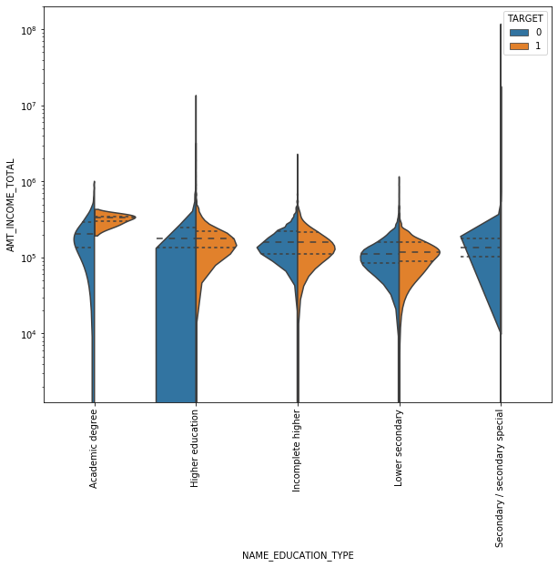

```python
# NAME_EDUCATION_TYPE vs AMT_INCOME_TOTAL vs TARGET

plt.figure(figsize=(10,8))
sns.violinplot(x = 'NAME_EDUCATION_TYPE', y= 'AMT_INCOME_TOTAL', hue='TARGET', split=True, data = application_data,inner="quartile", height=5, aspect=3)
plt.yscale('log')
plt.xticks(rotation=90);
```

#### Type of Income vs Amount of Income

- For the same average income across income types, clients with Secondary Education have the lowest probability of default.
- Among clients with an Academic Degree, median income of clients with payment difficulties is higher than all other cases.
- Among clients with Higher Education, Incomplete Higher Education and Lower Secondary education, the median income has no correlation with risk of default.

```python
#'NAME_INCOME_TYPE vs NAME_EDUCATION_TYPE'
subset = application_data[['NAME_INCOME_TYPE','NAME_EDUCATION_TYPE','TARGET']]
subset = subset.dropna()
subset['TARGET'] = subset['TARGET'].astype('int')
# pivot table for percentage of default for education type vs income type
incomeTypevsEdu = pd.pivot_table(index='NAME_EDUCATION_TYPE', columns = 'NAME_INCOME_TYPE',aggfunc=[np.mean],data=subset)
incomeTypevsEdu
```

| NAME_INCOME_TYPE NAME_EDUCATION_TYPE | mean TARGET Businessman | mean TARGET Commercial associate | mean TARGET Maternity leave | mean TARGET Pensioner | mean TARGET State servant | mean TARGET Student | mean TARGET Unemployed | mean TARGET Working |
| --- | --- | --- | --- | --- | --- | --- | --- | --- |
| Academic degree | nan | 0.02 | nan | 0.00 | 0.00 | nan | nan | 0.03 |
| Higher education | 0.00 | 0.05 | 0.00 | 0.04 | 0.04 | 0.00 | 0.00 | 0.06 |
| Incomplete higher | nan | 0.08 | nan | 0.04 | 0.07 | 0.00 | 0.33 | 0.09 |
| Lower secondary | nan | 0.12 | nan | 0.07 | 0.08 | nan | nan | 0.15 |
| Secondary / secondary special | nan | 0.09 | 1.00 | 0.06 | 0.07 | 0.00 | 0.54 | 0.11 |

```python
# pivot table of the count of defaults for education type vs income type
pd.pivot_table(index='NAME_EDUCATION_TYPE', columns = 'NAME_INCOME_TYPE',aggfunc='count',data=subset)
```

| NAME_INCOME_TYPE NAME_EDUCATION_TYPE | TARGET Businessman | TARGET Commercial associate | TARGET Maternity leave | TARGET Pensioner | TARGET State servant | TARGET Student | TARGET Unemployed | TARGET Working |
| --- | --- | --- | --- | --- | --- | --- | --- | --- |
| Academic degree | nan | 43.00 | nan | 26.00 | 23.00 | nan | nan | 72.00 |
| Higher education | 10.00 | 24,025.00 | 3.00 | 8,188.00 | 8,863.00 | 6.00 | 6.00 | 33,762.00 |
| Incomplete higher | nan | 3,400.00 | nan | 518.00 | 770.00 | 1.00 | 3.00 | 5,585.00 |
| Lower secondary | nan | 460.00 | nan | 1,529.00 | 102.00 | nan | nan | 1,725.00 |
| Secondary / secondary special | nan | 43,689.00 | 2.00 | 45,101.00 | 11,945.00 | 11.00 | 13.00 | 117,630.00 |

#### Education Type & Income Type

- From the above pivot tables we could say that clients with Academic Degree have the least default risk.
- The highest volume of applications are from clients with Secondary education. Among them, the least default risk is posed by Pensioners.
- The next highest in terms of volume of applications is from clients with Higher Education. Among these, the least risk is posed by Pensioners and State Servants.
- Note that there's not enough application from Businessmen with Higher Education to conclusively say they have very low risk of default.
- Highest default risk is posed by Unemployed clients. Among them unemployed clients with Secondary Education have the higest risk of default.

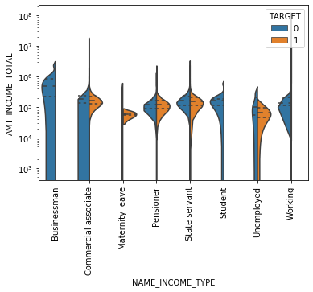

```python
sns.violinplot(x = 'NAME_INCOME_TYPE', y= 'AMT_INCOME_TOTAL', hue='TARGET', split=True, data = application_data,inner="quartile", height=5, aspect=3)
plt.yscale('log')
plt.xticks(rotation=90);
```

## Correlation Analysis

#### Correlation For Target : 0

```python
# function to correlate variables
def correlation(dataframe) :
    cor0=dataframe[columnsForAnalysis].corr()
    type(cor0)
    cor0.where(np.triu(np.ones(cor0.shape),k=1).astype(np.bool))
    cor0=cor0.unstack().reset_index()
    cor0.columns=['VAR1','VAR2','CORR']
    cor0.dropna(subset=['CORR'], inplace=True)
    cor0.CORR=round(cor0['CORR'],2)
    cor0.CORR=cor0.CORR.abs()
    cor0.sort_values(by=['CORR'],ascending=False)
    cor0=cor0[~(cor0['VAR1']==cor0['VAR2'])]
    return pd.DataFrame(cor0.sort_values(by=['CORR'],ascending=False))
```

```python
# Correlation for Target : 0
# Absolute values are reported
pd.set_option('precision', 2)
cor_0 = correlation(application_data0)
cor_0.style.background_gradient(cmap='GnBu').hide_index()
```

| VAR1 | VAR2 | CORR |
| --- | --- | --- |
| AMT_GOODS_PRICE | AMT_CREDIT | 0.99 |
| AMT_CREDIT | AMT_GOODS_PRICE | 0.99 |
| AMT_GOODS_PRICE | AMT_ANNUITY | 0.78 |
| AMT_ANNUITY | AMT_GOODS_PRICE | 0.78 |
| AMT_ANNUITY | AMT_CREDIT | 0.77 |
| AMT_CREDIT | AMT_ANNUITY | 0.77 |
| AGE_YEARS | DAYS_EMPLOYED | 0.63 |
| DAYS_EMPLOYED | AGE_YEARS | 0.63 |
| AMT_ANNUITY | AMT_INCOME_TOTAL | 0.42 |
| AMT_INCOME_TOTAL | AMT_ANNUITY | 0.42 |
| AMT_GOODS_PRICE | AMT_INCOME_TOTAL | 0.35 |
| AMT_INCOME_TOTAL | AMT_GOODS_PRICE | 0.35 |
| AMT_INCOME_TOTAL | AMT_CREDIT | 0.34 |
| AMT_CREDIT | AMT_INCOME_TOTAL | 0.34 |
| AGE_YEARS | EXT_SOURCE_3 | 0.20 |
| EXT_SOURCE_3 | AGE_YEARS | 0.20 |
| DAYS_LAST_PHONE_CHANGE | EXT_SOURCE_2 | 0.19 |
| EXT_SOURCE_2 | DAYS_LAST_PHONE_CHANGE | 0.19 |
| DAYS_EMPLOYED | AMT_INCOME_TOTAL | 0.14 |
| EXT_SOURCE_2 | AMT_INCOME_TOTAL | 0.14 |
| EXT_SOURCE_2 | AMT_GOODS_PRICE | 0.14 |
| AMT_INCOME_TOTAL | EXT_SOURCE_2 | 0.14 |
| AMT_INCOME_TOTAL | DAYS_EMPLOYED | 0.14 |
| AMT_GOODS_PRICE | EXT_SOURCE_2 | 0.14 |
| AMT_ANNUITY | EXT_SOURCE_2 | 0.13 |
| EXT_SOURCE_2 | AMT_ANNUITY | 0.13 |
| AMT_CREDIT | EXT_SOURCE_2 | 0.13 |
| EXT_SOURCE_2 | AMT_CREDIT | 0.13 |
| DAYS_EMPLOYED | EXT_SOURCE_3 | 0.11 |
| EXT_SOURCE_3 | DAYS_EMPLOYED | 0.11 |

[output cut: 60 more lines]

### Top 10 correlations for Target : 0 are

- AMT_GOODS_PRICE & AMT_CREDIT
- AMT_GOODS_PRICE & AMT_ANNUITY
- AMT_ANNUITY & AMT_CREDIT
- AGE_YEARS & DAYS_EMPLOYED
- AMT_ANNUITY & AMT_INCOME_TOTAL
- AMT_GOODS_PRICE & AMT_INCOME_TOTAL
- AMT_INCOME_TOTAL & AMT_CREDIT
- AGE_YEARS & EXT_SOURCE_3
- DAYS_LAST_PHONE_CHANGE & EXT_SOURCE_2
- DAYS_EMPLOYED & AMT_INCOME_TOTAL

#### Correlation For Target : 1

```python
# Correlation for Target : 1
# Absolute values are reported
pd.set_option('precision', 2)
cor_1 = correlation(application_data1)
cor_1.style.background_gradient(cmap='GnBu').hide_index()
```

| VAR1 | VAR2 | CORR |
| --- | --- | --- |
| AMT_GOODS_PRICE | AMT_CREDIT | 0.98 |
| AMT_CREDIT | AMT_GOODS_PRICE | 0.98 |
| AMT_CREDIT | AMT_ANNUITY | 0.75 |
| AMT_ANNUITY | AMT_GOODS_PRICE | 0.75 |
| AMT_ANNUITY | AMT_CREDIT | 0.75 |
| AMT_GOODS_PRICE | AMT_ANNUITY | 0.75 |
| AGE_YEARS | DAYS_EMPLOYED | 0.58 |
| DAYS_EMPLOYED | AGE_YEARS | 0.58 |
| EXT_SOURCE_2 | DAYS_LAST_PHONE_CHANGE | 0.21 |
| DAYS_LAST_PHONE_CHANGE | EXT_SOURCE_2 | 0.21 |
| EXT_SOURCE_3 | AGE_YEARS | 0.17 |
| AGE_YEARS | EXT_SOURCE_3 | 0.17 |
| AGE_YEARS | AMT_GOODS_PRICE | 0.14 |
| AGE_YEARS | AMT_CREDIT | 0.14 |
| AMT_GOODS_PRICE | AGE_YEARS | 0.14 |
| AMT_CREDIT | AGE_YEARS | 0.14 |
| AMT_GOODS_PRICE | EXT_SOURCE_2 | 0.13 |
| EXT_SOURCE_2 | AMT_GOODS_PRICE | 0.13 |
| AMT_CREDIT | EXT_SOURCE_2 | 0.12 |
| EXT_SOURCE_2 | AMT_ANNUITY | 0.12 |
| AMT_ANNUITY | EXT_SOURCE_2 | 0.12 |
| DAYS_LAST_PHONE_CHANGE | AMT_GOODS_PRICE | 0.12 |
| AMT_GOODS_PRICE | DAYS_LAST_PHONE_CHANGE | 0.12 |
| EXT_SOURCE_2 | AMT_CREDIT | 0.12 |
| EXT_SOURCE_2 | AGE_YEARS | 0.11 |
| AGE_YEARS | DAYS_LAST_PHONE_CHANGE | 0.11 |
| AMT_CREDIT | DAYS_LAST_PHONE_CHANGE | 0.11 |
| DAYS_LAST_PHONE_CHANGE | AMT_CREDIT | 0.11 |
| DAYS_LAST_PHONE_CHANGE | AGE_YEARS | 0.11 |
| AGE_YEARS | EXT_SOURCE_2 | 0.11 |

[output cut: 60 more lines]

### Top 10 correlations for Target 1 are :

- AMT_GOODS_PRICE & AMT_CREDIT
- AMT_CREDIT & AMT_ANNUITY
- AMT_ANNUITY & AMT_GOODS_PRICE
- AGE_YEARS & DAYS_EMPLOYED
- EXT_SOURCE_2 & DAYS_LAST_PHONE_CHANGE
- EXT_SOURCE_3 & AGE_YEARS
- AGE_YEARS & AMT_GOODS_PRICE
- AGE_YEARS & AMT_CREDIT
- AMT_GOODS_PRICE & EXT_SOURCE_2
- AMT_CREDIT & EXT_SOURCE_2

## Kindly open the second IPython notebook for Merged Data Analysis